# MDGS 2021: Baseline Summary Report

# 1 Introduction

## 1.1 Context

The Maryland Green Schools Program (MDGS) is a sustainable schools certification program, and the signature program of the Maryland Association for Environmental and Outdoor Education (MAEOE). The MDGS program provides infrastructure, support, and a rigorous review process to certify any school in Maryland with sustainable school certification as a Maryland Green School.

The MDGS program has been essential to Maryland’s ability to connect with goals of the Chesapeake Bay Watershed Agreement, as well as helping schools achieve Maryland’s educational standards and graduation requirements for environmental literacy. Currently, nearly 30% of all Maryland schools (public and private) are certified Green Schools. In 2020, MAEOE received state funding to expand their efforts, with a goal of having 50% of all schools in the state certified by 2026.

To support ongoing strategic efforts to expand MDGS, it is critical to understand the geographic and demographic reach in relation to the full population of Maryland public and private schools. This analysis will be conducted in Spring 2021 with the latest certification data.

This report presents the data summary after initial data cleaning and analysis of data from the National Center for Educational Statistics (NCES) on the characteristics of schools and students across the full population of schools in Maryland, both public and private.

While the data presented here are not about MDGS specifically, these distributions will be the basis for comparison and analysis of MDGS data later this year to determine areas where the program has higher and lower penetration, and to identify opportunities for expanding the reach and diversity of schools in the state that become certified as Maryland Green Schools

# 2 The Population: All Maryland Schools

The first stage of analysis was to gather, wrangle, and descriptively analyze the baseline data about all schools in the state of Maryland – public and private. This is the full population of *potential* Green Schools, to which we will comparatively analyze the current certified Green Schools.

## 2.1 Public & Private

> *Graph Help: My data labels aren’t matching the underlying data. The 28% is on the 72% bar, and vice versa. What did I do wrong?

> *Data Formatting Help: I can’t figure out how to cleanly get a percentage using the summarize function. My issues:
> 1. getting it to automatically find the total N to divide the n() count by – it feels not reproducible that I manually entered the population size.
> 2. formatting the data as a % with the % sign - instead of a whole number.

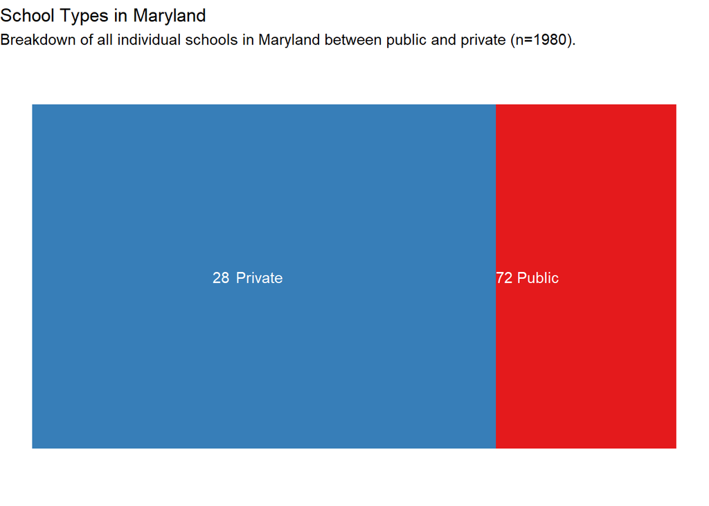

> *Graph Help: I like the “void” theme for stripping out all the graphic noise. But then I couldn’t figure out how to add back in the labels I want on the Y axis: the categories - Public, Magnet, Charter.

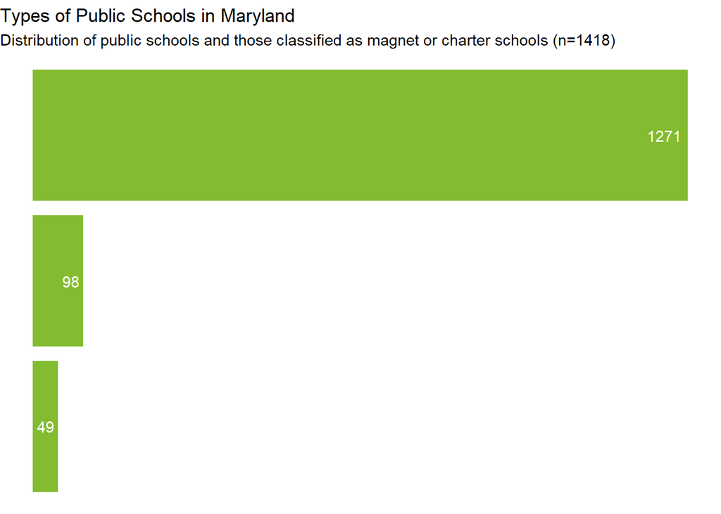

## 2.2 Schools by Grade Levels

Elementary schools are, by far, the most common type of school in Maryland. Nearly half of all schools in Maryland, across public and private schools, serve only elementary-aged students (K-5 or K-6). Another 14% of schools span a set of elementary and middle school grades.

The remainder of schools are in the higher grade levels – middle school, high school, or a spanning across all grade bands. Total enrollment ranged from a very small number of students (private schools) to 3,196 students (a suburban magnet high school). Schools for older students tend to serve more students per building.

> **Code Help:** In order to get these to organize by logical grade levels, ES, ES/MS, MS, HS, etc. – I think I need to get this variable turned into a factor. But I don’t know how to do that.

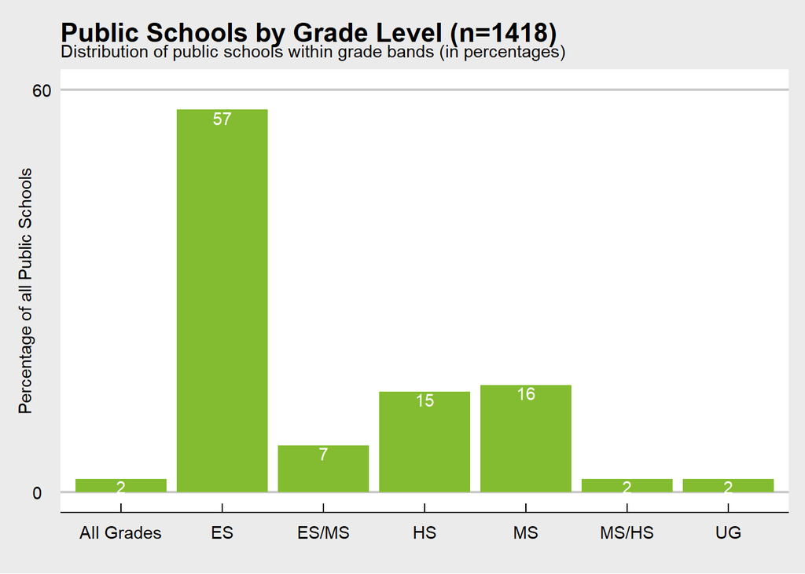

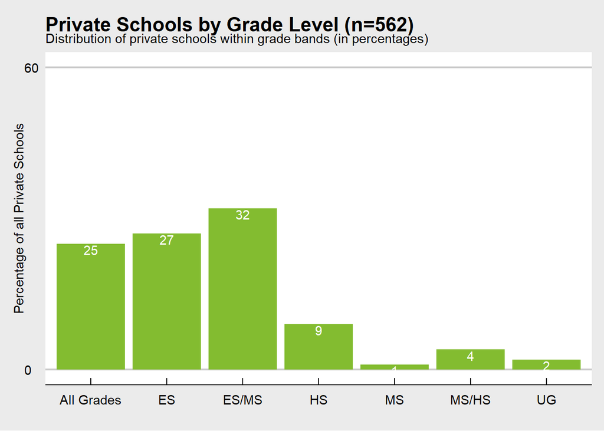

## 2.3 Locale Type

Most schools in Maryland are located in areas classified as suburbs by the NCES. Urban and rural schools are the next most common locales for schools. There are virtually no differences between the distribution of locales for public and private schools.

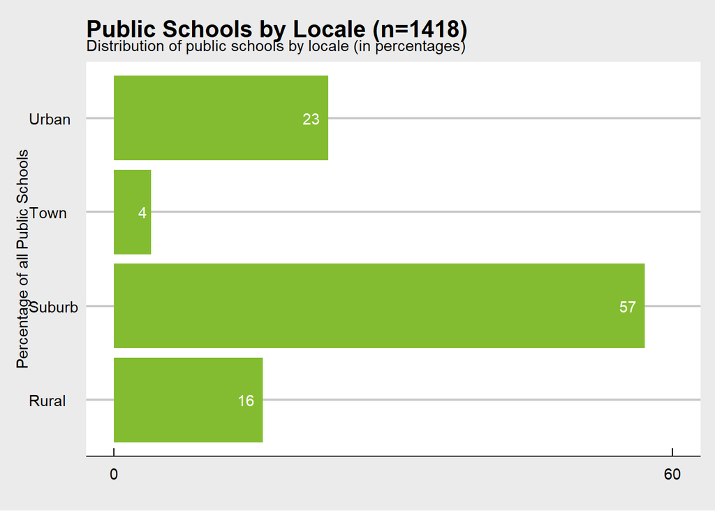

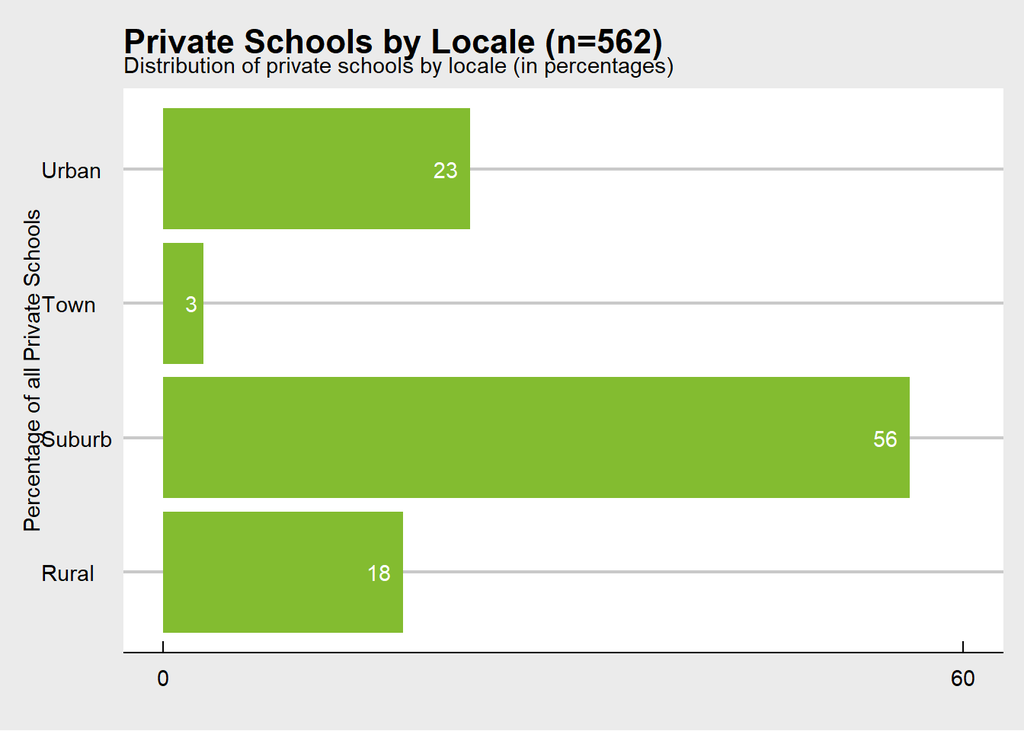